# Tugas Pertemuan 6

M.Syauqyi Habibi

## Package

```r
library(readxl)
library(forecast)
library(tseries)
library(TSA)
library(lmtest)
library(MASS)
library(ggplot2)
```

## Data

Data yang digunakan adalah sheet full data, berisi anomali suhu global bulanan.

```r
data <- read_excel("dataMPDW.xlsx")
colnames(data) <- c("timestamp", "anomali")
data$anomali <- as.numeric(data$anomali)
head(data)
```

| timestamp | anomali |
| --- | --- |
| 1984-12 | -0.05 |
| 1985-01 | 0.22 |
| 1985-02 | -0.04 |
| 1985-03 | 0.17 |
| 1985-04 | 0.12 |
| 1985-05 | 0.14 |

```r
str(data)
```

```
## tibble [500 × 2] (S3: tbl_df/tbl/data.frame)
##  $ timestamp: chr [1:500] "1984-12" "1985-01" "1985-02" "1985-03" ...
##  $ anomali  : num [1:500] -0.05 0.22 -0.04 0.17 0.12 0.14 0.15 0.04 0.17 0.13 ...
```

```r
cat("Jumlah data:", nrow(data), "\n")
```

```
## Jumlah data: 500
```

```r
cat("Data kosong:", sum(is.na(data$anomali)), "\n")
```

```
## Data kosong: 0
```

```r
summary(data$anomali)
```

```
##    Min. 1st Qu.  Median    Mean 3rd Qu.    Max.
## -0.0500  0.3900  0.6050  0.6274  0.8300  1.4800
```

Data diubah menjadi objek time series bulanan.

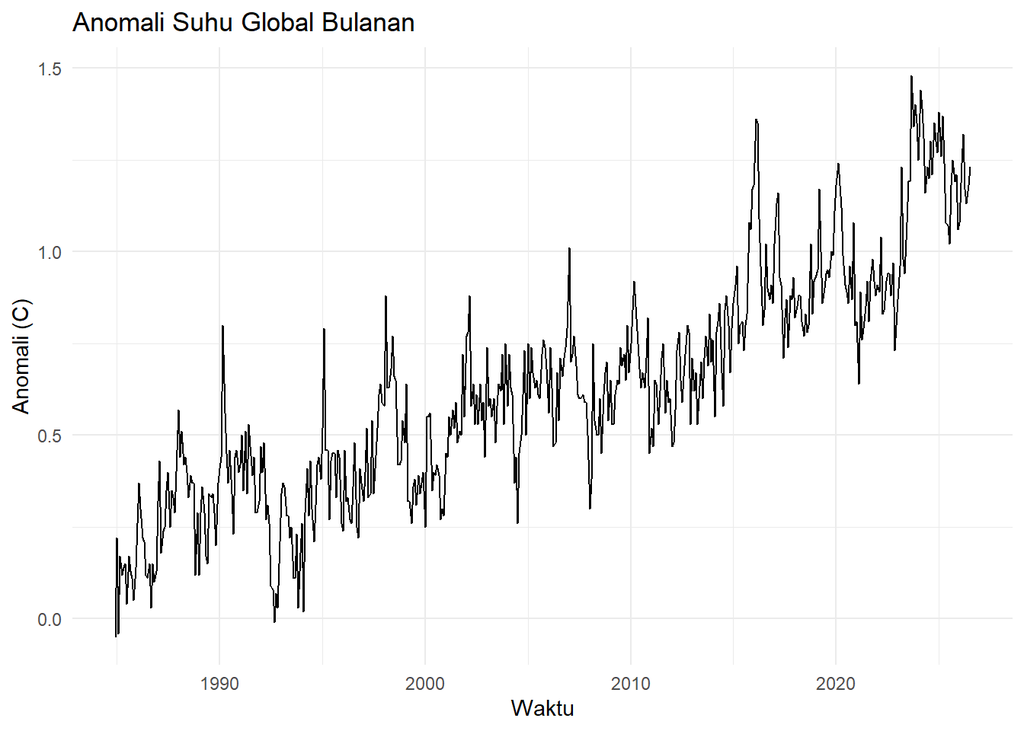

```r
awal <- as.numeric(strsplit(data$timestamp[1], "-")[[1]])
y <- ts(data$anomali, start = awal, frequency = 12)
autoplot(y) +
  labs(title = "Anomali Suhu Global Bulanan", x = "Waktu", y = "Anomali (C)") +
  theme_minimal()
```

Interpretasi: plot terlihat naik dari waktu ke waktu, sehingga ada indikasi tren dan data belum stasioner dalam rataan.

## Pembagian Data Train dan Test

Data dibagi 80% untuk train dan 20% untuk test.

```r
n <- length(y)
n_train <- floor(0.8 * n)
train <- ts(y[1:n_train], start = start(y), frequency = 12)
test <- ts(y[(n_train + 1):n], start = time(y)[n_train + 1], frequency = 12)
cat("Data train:", length(train), "\n")
```

```
## Data train: 400
```

```r
cat("Data test:", length(test), "\n")
```

```
## Data test: 100
```

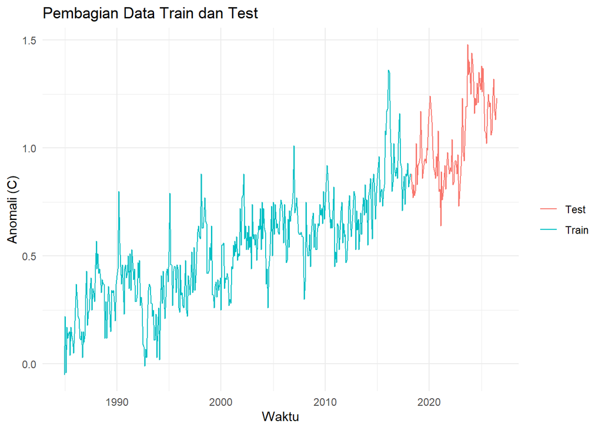

```r
autoplot(train, series = "Train") +
  autolayer(test, series = "Test") +
  labs(title = "Pembagian Data Train dan Test", x = "Waktu", y = "Anomali (C)", colour = "") +
  theme_minimal()
```

## Kestasioneran Data Train

### Plot Data Train

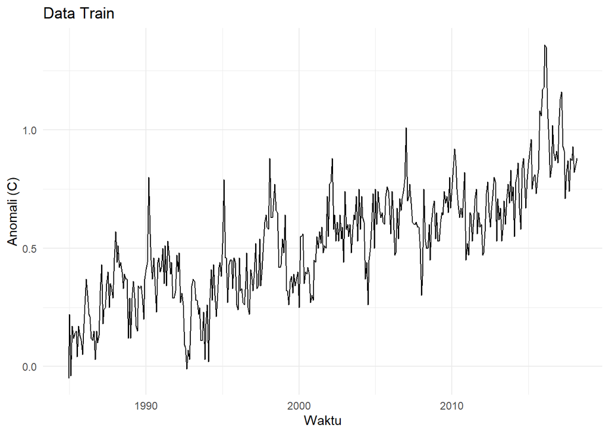

```r
autoplot(train) +
  labs(title = "Data Train", x = "Waktu", y = "Anomali (C)") +
  theme_minimal()
```

### Uji Stasioner dalam Rataan

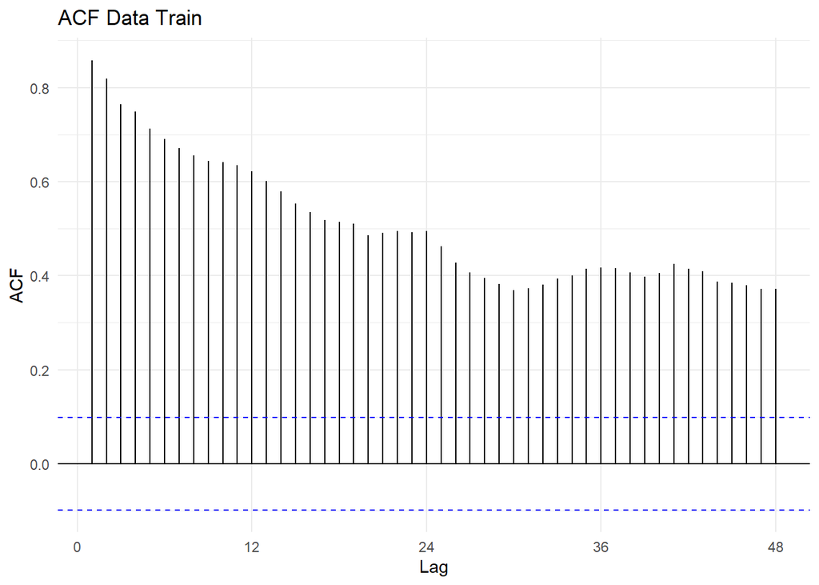

```r
ggAcf(train, lag.max = 48) + labs(title = "ACF Data Train") + theme_minimal()
```

Interpretasi: jika ACF turun sangat lambat (tails off slowly), data tidak stasioner dalam rataan.

```r
adf_train <- adf.test(train)
adf_train
```

```
##
##  Augmented Dickey-Fuller Test
##
## data:  train
## Dickey-Fuller = -4.9579, Lag order = 7, p-value = 0.01
## alternative hypothesis: stationary
```

Interpretasi: p-value = 0.01. P-value kurang dari 0.05, maka data stasioner dalam rataan.

### Uji Stasioner dalam Ragam

Box-Cox hanya bisa untuk data positif. Data anomali memiliki nilai negatif, maka data digeser dengan konstanta agar semua nilainya positif. Pergeseran ini tidak mengubah pola ragam.

```r
geser <- ifelse(min(train) <= 0, abs(min(train)) + 1, 0)
train_s <- train + geser
cat("Konstanta geser:", geser, "\n")
```

```
## Konstanta geser: 1.05
```

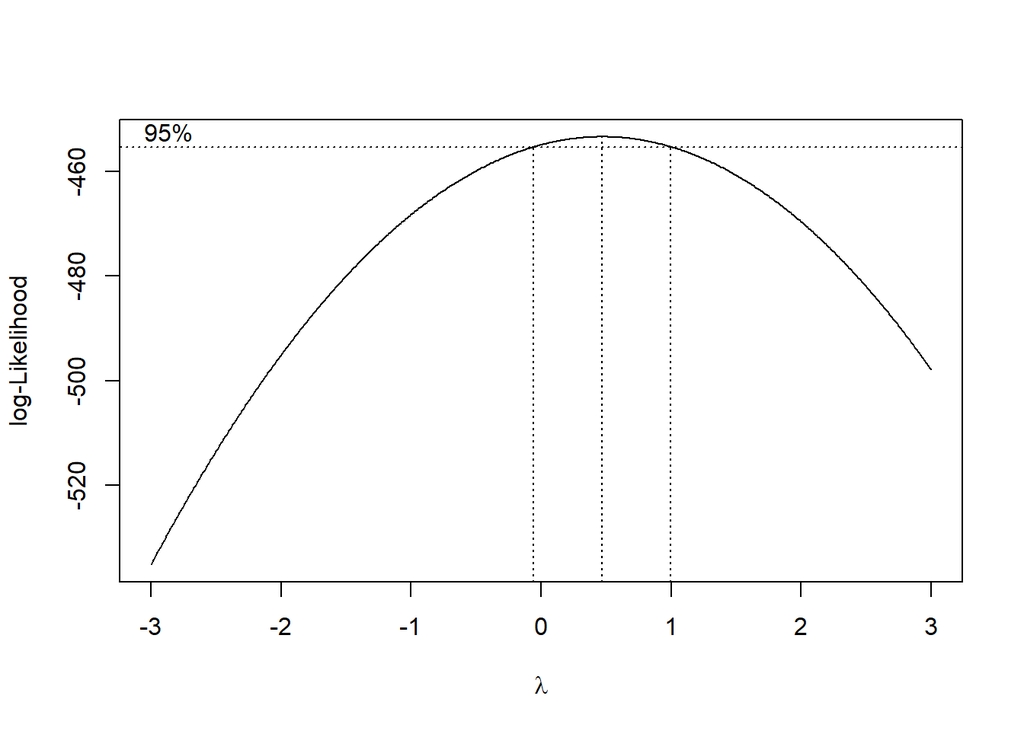

```r
bc <- boxcox(lm(as.numeric(train_s) ~ 1), lambda = seq(-3, 3, 0.01), plotit = TRUE)
```

```r
lambda_opt <- bc$x[which.max(bc$y)]
batas <- max(bc$y) - qchisq(0.95, 1) / 2
ci <- range(bc$x[bc$y >= batas])
hasil_bc <- data.frame(Lambda_optimum = lambda_opt, Batas_bawah = ci[1], Batas_atas = ci[2])
hasil_bc
```

| Lambda_optimum | Batas_bawah | Batas_atas |
| --- | --- | --- |
| 0.47 | -0.05 | 0.99 |

```r
ragam_stasioner <- ci[1] <= 1 & ci[2] >= 1
lam <- if (ragam_stasioner) NULL else lambda_opt
```

Interpretasi: selang kepercayaan 95% untuk lambda adalah -0.05 sampai 0.99. Selang tidak mengandung angka 1, maka data belum stasioner dalam ragam dan perlu transformasi Box-Cox.

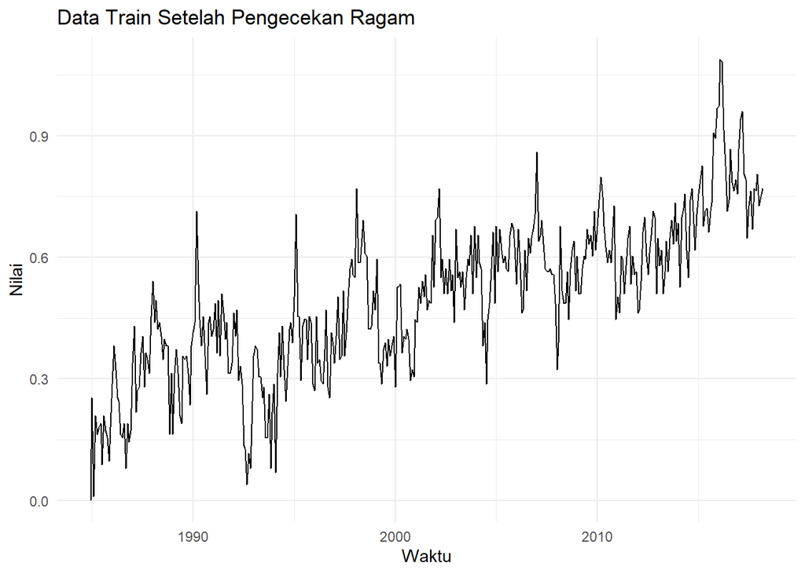

```r
train_t <- if (is.null(lam)) train_s else BoxCox(train_s, lam)
autoplot(train_t) +
  labs(title = "Data Train Setelah Pengecekan Ragam", x = "Waktu", y = "Nilai") +
  theme_minimal()
```

## Differencing

Differencing dilakukan sampai data stasioner dalam rataan. Orde differencing dicek dengan uji ADF.

```r
d <- 0
seri <- train_t
while (adf.test(seri)$p.value >= 0.05 & d < 3) {
  d <- d + 1
  seri <- diff(seri)
}
cat("Orde differencing (d):", d, "\n")
```

```
## Orde differencing (d): 0
```

```r
adf_diff <- adf.test(seri)
adf_diff
```

```
##
##  Augmented Dickey-Fuller Test
##
## data:  seri
## Dickey-Fuller = -5.0372, Lag order = 7, p-value = 0.01
## alternative hypothesis: stationary
```

Interpretasi: Data sudah stasioner, tidak perlu differencing.

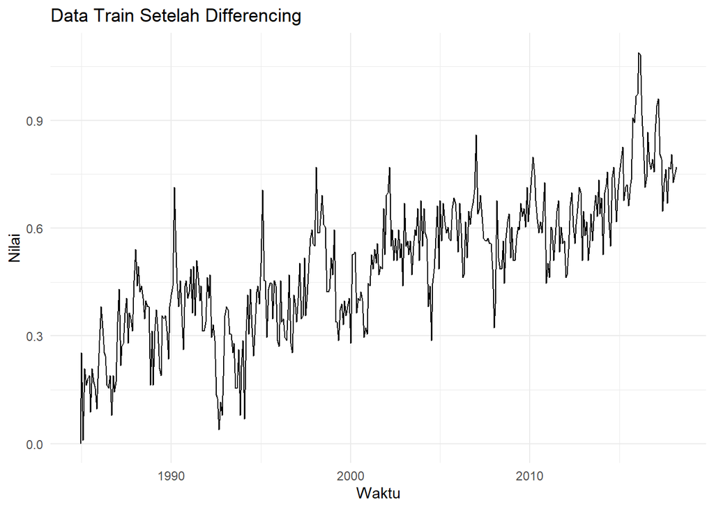

```r
autoplot(seri) +
  labs(title = "Data Train Setelah Differencing", x = "Waktu", y = "Nilai") +
  theme_minimal()
```

## Identifikasi Model

### ACF dan PACF

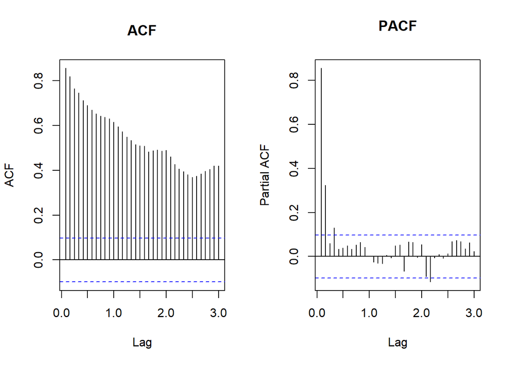

```r
par(mfrow = c(1, 2))
acf(seri, lag.max = 36, main = "ACF")
pacf(seri, lag.max = 36, main = "PACF")
```

```r
par(mfrow = c(1, 1))
```

Interpretasi: lag ACF yang keluar batas menunjukkan kandidat orde q. Lag PACF yang keluar batas menunjukkan kandidat orde p.

### EACF

```r
TSA::eacf(seri, ar.max = 6, ma.max = 6)
```

```
## AR/MA
##   0 1 2 3 4 5 6
## 0 x x x x x x x
## 1 x o x o o o o
## 2 x x x o o o o
## 3 x x o o o o o
## 4 x x x o o o o
## 5 x o o o o o o
## 6 x x o o o o o
```

Interpretasi: kandidat model diambil dari pojok kiri atas segitiga simbol o pada tabel EACF.

### Kandidat Model

Kandidat model disusun dari hasil ACF, PACF, dan EACF. Kandidat dibuat dengan orde p dan q kecil.

```r
kandidat <- data.frame(
  p = c(0, 1, 0, 1, 2, 2, 0, 1),
  q = c(1, 0, 2, 1, 0, 1, 3, 2)
)
kandidat$d <- d
kandidat$model <- paste0("ARIMA(", kandidat$p, ",", kandidat$d, ",", kandidat$q, ")")
kandidat
```

| p | q | d | model |
| --- | --- | --- | --- |
| 0 | 1 | 0 | ARIMA(0,0,1) |
| 1 | 0 | 0 | ARIMA(1,0,0) |
| 0 | 2 | 0 | ARIMA(0,0,2) |
| 1 | 1 | 0 | ARIMA(1,0,1) |
| 2 | 0 | 0 | ARIMA(2,0,0) |
| 2 | 1 | 0 | ARIMA(2,0,1) |
| 0 | 3 | 0 | ARIMA(0,0,3) |
| 1 | 2 | 0 | ARIMA(1,0,2) |

## Pendugaan Parameter dan Pemilihan Model

Setiap kandidat diduga parameternya. Model dipilih jika semua parameter signifikan (p-value kurang dari 0.05) dan nilai AIC kecil.

```r
fit_model <- function(p, d, q) {
  tryCatch(Arima(train_s, order = c(p, d, q), lambda = lam, method = "ML"),
           error = function(e) NULL)
}

semua_model <- list()
tabel <- data.frame()

for (i in seq_len(nrow(kandidat))) {
  m <- fit_model(kandidat$p[i], kandidat$d[i], kandidat$q[i])
  if (is.null(m)) next
  uji <- coeftest(m)
  semua_model[[kandidat$model[i]]] <- m
  tabel <- rbind(tabel, data.frame(
    Model = kandidat$model[i],
    AIC = AIC(m),
    BIC = BIC(m),
    Semua_signifikan = all(uji[, 4] < 0.05)
  ))
}
tabel <- tabel[order(tabel$AIC), ]
tabel
```

|  | Model | AIC | BIC | Semua_signifikan |
| --- | --- | --- | --- | --- |
| 6 | ARIMA(2,0,1) | -785.4629 | -765.5055 | TRUE |
| 4 | ARIMA(1,0,1) | -784.6360 | -768.6702 | TRUE |
| 8 | ARIMA(1,0,2) | -783.7765 | -763.8192 | FALSE |
| 5 | ARIMA(2,0,0) | -775.4148 | -759.4490 | TRUE |
| 2 | ARIMA(1,0,0) | -731.7425 | -719.7681 | TRUE |
| 7 | ARIMA(0,0,3) | -612.9401 | -592.9828 | TRUE |
| 3 | ARIMA(0,0,2) | -565.8247 | -549.8588 | TRUE |
| 1 | ARIMA(0,0,1) | -424.1614 | -412.1870 | TRUE |

### Uji Signifikansi Parameter

```r
for (nm in tabel$Model) {
  cat("\n", nm, "\n")
  print(coeftest(semua_model[[nm]]))
}
```

```
##
##  ARIMA(2,0,1)
##
## z test of coefficients:
##
##           Estimate Std. Error z value  Pr(>|z|)
## ar1        1.25648    0.13960  9.0009 < 2.2e-16 ***
## ar2       -0.26688    0.13244 -2.0151    0.0439 *
## ma1       -0.71882    0.11592 -6.2009 5.613e-10 ***
## intercept  0.48588    0.10461  4.6447 3.405e-06 ***
## ---
## Signif. codes:  0 '***' 0.001 '**' 0.01 '*' 0.05 '.' 0.1 ' ' 1
##
##
##  ARIMA(1,0,1)
##
## z test of coefficients:
##
##            Estimate Std. Error z value  Pr(>|z|)
## ar1        0.969643   0.014729 65.8313 < 2.2e-16 ***
## ma1       -0.461943   0.056587 -8.1634 3.257e-16 ***
## intercept  0.490467   0.073912  6.6358 3.227e-11 ***
## ---
## Signif. codes:  0 '***' 0.001 '**' 0.01 '*' 0.05 '.' 0.1 ' ' 1
##
##
##  ARIMA(1,0,2)
##
## z test of coefficients:
##
##            Estimate Std. Error z value  Pr(>|z|)
## ar1        0.976330   0.014187 68.8178 < 2.2e-16 ***
## ma1       -0.459922   0.053002 -8.6774 < 2.2e-16 ***
## ma2       -0.058634   0.054848 -1.0690    0.2851
## intercept  0.487549   0.083158  5.8630 4.547e-09 ***
## ---
## Signif. codes:  0 '***' 0.001 '**' 0.01 '*' 0.05 '.' 0.1 ' ' 1
##
##
##  ARIMA(2,0,0)
```

[output cut: 41 more lines]

```
## ma2       0.514917   0.035499  14.505 < 2.2e-16 ***
## intercept 0.496706   0.013287  37.383 < 2.2e-16 ***
## ---
## Signif. codes:  0 '***' 0.001 '**' 0.01 '*' 0.05 '.' 0.1 ' ' 1
##
##
##  ARIMA(0,0,1)
##
## z test of coefficients:
##
##           Estimate Std. Error z value  Pr(>|z|)
## ma1       0.607673   0.029252  20.773 < 2.2e-16 ***
## intercept 0.496677   0.011344  43.784 < 2.2e-16 ***
## ---
## Signif. codes:  0 '***' 0.001 '**' 0.01 '*' 0.05 '.' 0.1 ' ' 1
```

### Model Terbaik

```r
layak <- tabel[tabel$Semua_signifikan, ]
if (nrow(layak) == 0) layak <- tabel
nama_terbaik <- layak$Model[which.min(layak$AIC)]
model_terbaik <- semua_model[[nama_terbaik]]
cat("Model terbaik:", nama_terbaik, "\n")
```

```
## Model terbaik: ARIMA(2,0,1)
```

```r
summary(model_terbaik)
```

```
## Series: train_s
## ARIMA(2,0,1) with non-zero mean
## Box Cox transformation: lambda= 0.47
##
## Coefficients:
##          ar1      ar2      ma1    mean
##       1.2565  -0.2669  -0.7188  0.4859
## s.e.  0.1396   0.1324   0.1159  0.1046
##
## sigma^2 = 0.008053:  log likelihood = 397.73
## AIC=-785.46   AICc=-785.31   BIC=-765.51
##
## Training set error measures:
##                       ME      RMSE        MAE         MPE    MAPE      MASE
## Training set 0.007207467 0.1128724 0.09077297 -0.03238309 5.87378 0.6014329
##                     ACF1
## Training set -0.02478685
```

Interpretasi: model terbaik adalah **ARIMA(2,0,1)**, yaitu model dengan semua parameter signifikan dan AIC terkecil.

## Analisis Sisaan

```r
sisaan <- as.numeric(residuals(model_terbaik))
```

### Plot Sisaan

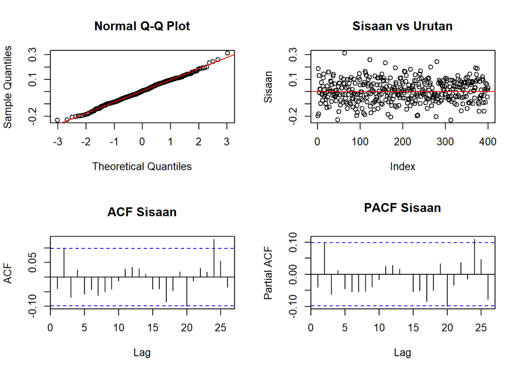

```r
par(mfrow = c(2, 2))
qqnorm(sisaan); qqline(sisaan, col = "red")
plot(sisaan, type = "p", main = "Sisaan vs Urutan", ylab = "Sisaan"); abline(h = 0, col = "red")
acf(sisaan, main = "ACF Sisaan")
pacf(sisaan, main = "PACF Sisaan")
```

```r
par(mfrow = c(1, 1))
```

Interpretasi: titik QQ-plot yang mengikuti garis menandakan sisaan menyebar normal. Sisaan yang acak di sekitar nol dan tidak ada lag ACF yang keluar batas menandakan model baik.

### Uji Normalitas

```r
sw <- shapiro.test(sisaan)
ks <- ks.test(sisaan, "pnorm", mean(sisaan), sd(sisaan))
sw
```

```
##
##  Shapiro-Wilk normality test
##
## data:  sisaan
## W = 0.9968, p-value = 0.6198
```

```r
ks
```

```
##
##  Asymptotic one-sample Kolmogorov-Smirnov test
##
## data:  sisaan
## D = 0.032566, p-value = 0.79
## alternative hypothesis: two-sided
```

Interpretasi: p-value Shapiro-Wilk = 0.6198. Sisaan menyebar normal. P-value Kolmogorov-Smirnov = 0.79. Sisaan menyebar normal.

### Uji Autokorelasi

```r
lb <- Box.test(sisaan, lag = 20, type = "Ljung-Box", fitdf = length(coef(model_terbaik)))
lb
```

```
##
##  Box-Ljung test
##
## data:  sisaan
## X-squared = 23.361, df = 16, p-value = 0.1044
```

Interpretasi: p-value = 0.1044. Tidak ada autokorelasi pada sisaan.

### Uji Kehomogenan Ragam

Uji dilakukan dengan Ljung-Box pada kuadrat sisaan.

```r
lb2 <- Box.test(sisaan^2, lag = 20, type = "Ljung-Box")
lb2
```

```
##
##  Box-Ljung test
##
## data:  sisaan^2
## X-squared = 15.798, df = 20, p-value = 0.7291
```

Interpretasi: p-value = 0.7291. Ragam sisaan homogen.

### Uji Nilai Tengah Sisaan

```r
tt <- t.test(sisaan, mu = 0)
tt
```

```
##
##  One Sample t-test
##
## data:  sisaan
## t = 0.94707, df = 399, p-value = 0.3442
## alternative hypothesis: true mean is not equal to 0
## 95 percent confidence interval:
##  -0.004549231  0.013006546
## sample estimates:
##   mean of x
## 0.004228657
```

Interpretasi: p-value = 0.3442. Nilai tengah sisaan sama dengan nol.

## Overfitting

Model terbaik dibandingkan dengan model yang orde p atau q-nya ditambah satu.

```r
ord <- arimaorder(model_terbaik)
p0 <- ord[1]; d0 <- ord[2]; q0 <- ord[3]

over <- list(
  c(p0 + 1, d0, q0),
  c(p0, d0, q0 + 1)
)

tabel_over <- data.frame(Model = nama_terbaik, AIC = AIC(model_terbaik),
                         Semua_signifikan = all(coeftest(model_terbaik)[, 4] < 0.05))
for (o in over) {
  m <- fit_model(o[1], o[2], o[3])
  if (is.null(m)) next
  tabel_over <- rbind(tabel_over, data.frame(
    Model = paste0("ARIMA(", o[1], ",", o[2], ",", o[3], ")"),
    AIC = AIC(m),
    Semua_signifikan = all(coeftest(m)[, 4] < 0.05)
  ))
  semua_model[[tail(tabel_over$Model, 1)]] <- m
}
tabel_over
```

| Model | AIC | Semua_signifikan |
| --- | --- | --- |
| ARIMA(2,0,1) | -785.4629 | TRUE |
| ARIMA(3,0,1) | -791.4287 | TRUE |
| ARIMA(2,0,2) | -781.5704 | FALSE |

```r
for (nm in tabel_over$Model[-1]) {
  cat("\n", nm, "\n")
  print(coeftest(semua_model[[nm]]))
}
```

```
##
##  ARIMA(3,0,1)
##
## z test of coefficients:
##
##            Estimate Std. Error  z value  Pr(>|z|)
## ar1        1.434217   0.066913  21.4342 < 2.2e-16 ***
## ar2       -0.237436   0.087524  -2.7128 0.0066714 **
## ar3       -0.197725   0.059572  -3.3191 0.0009032 ***
## ma1       -0.927605   0.041991 -22.0904 < 2.2e-16 ***
## intercept  0.491424   0.200441   2.4517 0.0142178 *
## ---
## Signif. codes:  0 '***' 0.001 '**' 0.01 '*' 0.05 '.' 0.1 ' ' 1
##
##
##  ARIMA(2,0,2)
##
## z test of coefficients:
##
##            Estimate Std. Error z value  Pr(>|z|)
## ar1        0.111161   0.189253  0.5874  0.556956
## ar2        0.828422   0.185321  4.4702 7.815e-06 ***
## ma1        0.392163   0.199312  1.9676  0.049116 *
## ma2       -0.360804   0.120174 -3.0023  0.002679 **
## intercept  0.487729   0.071531  6.8184 9.207e-12 ***
## ---
## Signif. codes:  0 '***' 0.001 '**' 0.01 '*' 0.05 '.' 0.1 ' ' 1
```

Interpretasi: model overfitting dianggap lebih baik jika semua parameternya signifikan dan AIC lebih kecil. Jika tidak, model terbaik awal tetap dipakai.

```r
lebih_baik <- tabel_over[-1, ]
lebih_baik <- lebih_baik[lebih_baik$Semua_signifikan & lebih_baik$AIC < tabel_over$AIC[1], ]
if (nrow(lebih_baik) > 0) {
  model_final_nama <- lebih_baik$Model[which.min(lebih_baik$AIC)]
} else {
  model_final_nama <- nama_terbaik
}
model_final <- semua_model[[model_final_nama]]
cat("Model final:", model_final_nama, "\n")
```

```
## Model final: ARIMA(3,0,1)
```

Interpretasi: model final yang digunakan untuk peramalan adalah **ARIMA(3,0,1)**.

## Peramalan

### Peramalan pada Data Test

```r
h <- length(test)
fc <- forecast(model_final, h = h)
fc_mean <- as.numeric(fc$mean) - geser
fc_lo <- as.numeric(fc$lower[, 2]) - geser
fc_hi <- as.numeric(fc$upper[, 2]) - geser
hasil_fc <- data.frame(Waktu = as.numeric(time(test)), Aktual = as.numeric(test),
                       Ramalan = fc_mean, Bawah95 = fc_lo, Atas95 = fc_hi)
head(hasil_fc, 12)
```

|  | Waktu | Aktual | Ramalan | Bawah95 | Atas95 |
| --- | --- | --- | --- | --- | --- |
| 1 | 2018.250 | 0.88 | 0.8722093 | 0.6342337 | 1.126913 |
| 2 | 2018.333 | 0.81 | 0.8744020 | 0.6085919 | 1.161235 |
| 3 | 2018.417 | 0.77 | 0.8734496 | 0.5845522 | 1.187372 |
| 4 | 2018.500 | 0.83 | 0.8731025 | 0.5709890 | 1.202701 |
| 5 | 2018.583 | 0.78 | 0.8723972 | 0.5607430 | 1.213400 |
| 6 | 2018.667 | 0.80 | 0.8716566 | 0.5529975 | 1.221079 |
| 7 | 2018.750 | 1.02 | 0.8708306 | 0.5466373 | 1.226936 |
| 8 | 2018.833 | 0.83 | 0.8699613 | 0.5411988 | 1.231606 |
| 9 | 2018.917 | 0.92 | 0.8690572 | 0.5363600 | 1.235488 |
| 10 | 2019.000 | 0.93 | 0.8681304 | 0.5319334 | 1.238831 |

[output cut: 2 more lines]

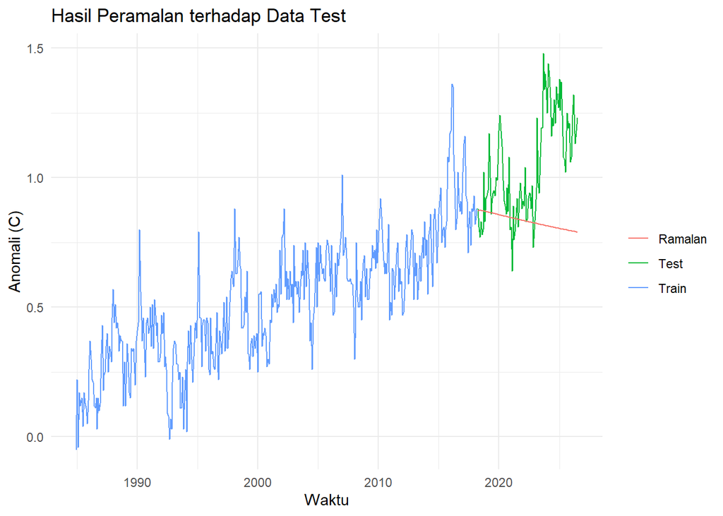

```r
fc_ts <- ts(fc_mean, start = start(test), frequency = 12)
autoplot(train, series = "Train") +
  autolayer(test, series = "Test") +
  autolayer(fc_ts, series = "Ramalan") +
  labs(title = "Hasil Peramalan terhadap Data Test", x = "Waktu", y = "Anomali (C)", colour = "") +
  theme_minimal()
```

### Akurasi Peramalan

```r
aktual <- as.numeric(test)
galat <- aktual - fc_mean
akurasi <- data.frame(
  RMSE = sqrt(mean(galat^2)),
  MAE = mean(abs(galat)),
  MAPE = mean(abs(galat / aktual)) * 100
)
akurasi
```

| RMSE | MAE | MAPE |
| --- | --- | --- |
| 0.2982446 | 0.2323775 | 19.97685 |

Interpretasi: semakin kecil nilai RMSE dan MAE, semakin dekat ramalan dengan data aktual. MAPE kurang cocok untuk data ini jika ada nilai aktual mendekati nol.

### Peramalan ke Depan

Model dilatih ulang dengan seluruh data, lalu digunakan untuk meramalkan 24 bulan ke depan.

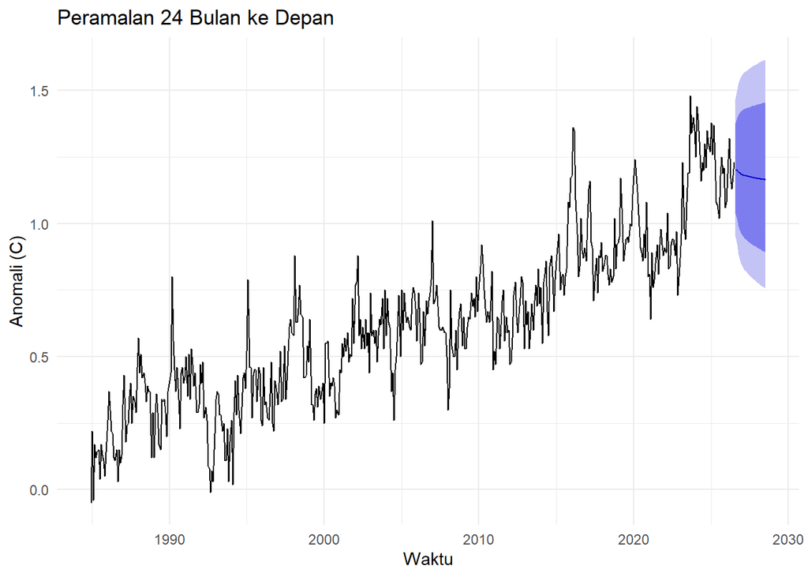

```r
ord_f <- arimaorder(model_final)
y_s <- y + geser
model_full <- Arima(y_s, order = ord_f[1:3], lambda = lam, method = "ML")
fc_depan <- forecast(model_full, h = 24)
fc_depan$mean <- fc_depan$mean - geser
fc_depan$lower <- fc_depan$lower - geser
fc_depan$upper <- fc_depan$upper - geser
fc_depan$x <- fc_depan$x - geser

autoplot(fc_depan) +
  labs(title = "Peramalan 24 Bulan ke Depan", x = "Waktu", y = "Anomali (C)") +
  theme_minimal()
```

```r
data.frame(Waktu = format(as.Date(paste0(floor(time(fc_depan$mean)), "-",
                                         round((time(fc_depan$mean) %% 1) * 12) + 1, "-01")), "%Y-%m"),
           Ramalan = round(as.numeric(fc_depan$mean), 3),
           Bawah95 = round(as.numeric(fc_depan$lower[, 2]), 3),
           Atas95 = round(as.numeric(fc_depan$upper[, 2]), 3))
```

| Waktu | Ramalan | Bawah95 | Atas95 |
| --- | --- | --- | --- |
| 2026-08 | 1.203 | 0.952 | 1.470 |
| 2026-09 | 1.201 | 0.919 | 1.503 |
| 2026-10 | 1.194 | 0.887 | 1.526 |
| 2026-11 | 1.191 | 0.868 | 1.540 |
| 2026-12 | 1.187 | 0.854 | 1.550 |
| 2027-01 | 1.185 | 0.843 | 1.557 |
| 2027-02 | 1.183 | 0.834 | 1.563 |
| 2027-03 | 1.181 | 0.826 | 1.568 |
| 2027-04 | 1.179 | 0.820 | 1.572 |
| 2027-05 | 1.178 | 0.814 | 1.576 |

[output cut: 14 more lines]